# k Nearest Neighbour (kNN) with Python

###### By Rohit Pardasani

**k-nearest neighbors algorithm (k-NN)** is a non-parametric classification method  
In **k-NN classification**, the output is a class membership. An object is classified by a plurality vote of its neighbors, with the object being assigned to the class most common among its k nearest neighbors (k is a positive integer, typically small).  
If k = 1, then the object is simply assigned to the class of that single nearest neighbor. In k-NN regression, the output is the property value for the object. This value is the average of the values of k nearest neighbors.  
In **k-NN regression**, the output is the property value for the object. This value is the average of the values of k nearest neighbors.

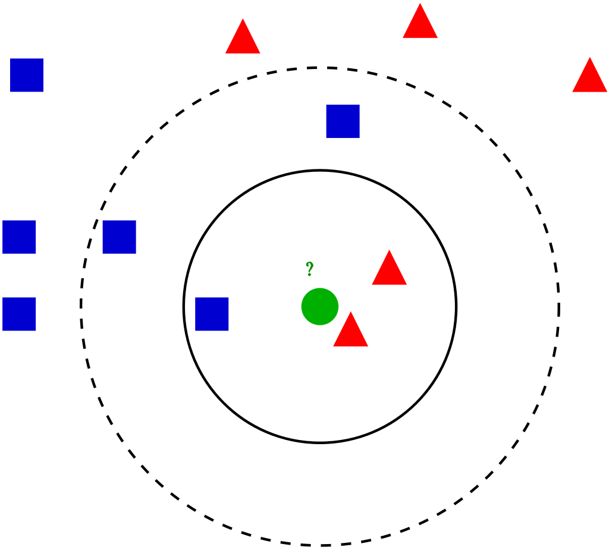

**Example of k-NN classification.** The test sample (green dot) should be classified either to blue squares or to red triangles.  
If k = 3 (solid line circle) it is assigned to the red triangles because there are 2 triangles and only 1 square inside the inner circle.  
If k = 5 (dashed line circle) it is assigned to the blue squares (3 squares vs. 2 triangles inside the outer circle).

The best choice of k depends upon the data; generally, larger values of k reduces effect of the noise on the classification, but make boundaries between classes less distinct.  
A good k can be selected by various heuristic techniques.  
The special case where the class is predicted to be the class of the closest training sample (i.e. when k = 1) is called the nearest neighbor algorithm.

|  | X | Y | Class |
| --- | --- | --- | --- |
| 0 | 1.690526 | 1.093517 | Class 1 |
| 1 | -0.465937 | 5.109161 | Class 1 |
| 2 | 0.032820 | 4.247762 | Class 1 |
| 3 | 0.407516 | 4.548920 | Class 1 |
| 4 | -0.788923 | 0.946951 | Class 1 |
| 5 | 0.002066 | 7.301399 | Class 1 |
| 6 | -0.000890 | 4.308671 | Class 1 |
| 7 | -1.754724 | 3.225720 | Class 1 |
| 8 | 1.017658 | 8.058144 | Class 1 |
| 9 | 0.600499 | 3.909228 | Class 1 |
| 10 | -0.625429 | 1.098643 | Class 1 |
| 11 | -0.171548 | 3.189544 | Class 1 |
| 12 | 0.505299 | -0.576630 | Class 1 |
| 13 | -0.261356 | 6.098793 | Class 1 |
| 14 | -0.242749 | 3.167051 | Class 1 |
| 15 | 3.514893 | 1.912019 | Class 2 |
| 16 | 7.144940 | 0.237302 | Class 2 |
| 17 | 1.697849 | 0.101434 | Class 2 |
| 18 | 6.070859 | 0.252578 | Class 2 |
| 19 | 0.871170 | -0.132377 | Class 2 |
| 20 | 3.675681 | -0.309476 | Class 2 |
| 21 | 2.591560 | -1.434963 | Class 2 |
| 22 | 7.923951 | 0.501624 | Class 2 |
| 23 | 8.532322 | -0.094775 | Class 2 |
| 24 | 4.341172 | 1.193086 | Class 2 |
| 25 | 6.681466 | -0.368818 | Class 2 |
| 26 | 4.640027 | -1.906370 | Class 2 |
| 27 | 6.136124 | -0.099611 | Class 2 |
| 28 | 3.494326 | 1.699537 | Class 2 |
| 29 | 1.583322 | -0.383423 | Class 2 |
| 30 | 1.393803 | -0.889857 | Class 2 |
| 31 | 5.766244 | -1.193592 | Class 2 |
| 32 | 9.495190 | -1.050017 | Class 2 |
| 33 | 5.538823 | -0.300194 | Class 2 |
| 34 | 3.950791 | -1.179982 | Class 2 |

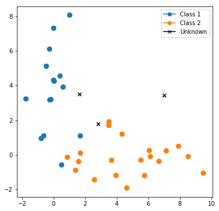

```python
import numpy as np
import matplotlib.pyplot as plt
import pandas as pd
from matplotlib.lines import Line2D
plt.figure(figsize=(6, 6))
legend_elements = [Line2D([0], [0], marker='o', color='#1f77b4', label='Class 1'),
                   Line2D([0], [0], marker='o', color='#ff7f0e', label='Class 2'),
                   Line2D([0], [0], marker='x', color='black', label='Unknown')]
np.random.seed(7)
colordict = {'Class 1':'#1f77b4','Class 2':'#ff7f0e'}
x1 = np.random.normal(loc=0.0, scale=1.0, size=15)
y1 = np.random.normal(loc=4.0, scale=2.0, size=15)
x2 = np.random.normal(loc=5.0, scale=2.0, size=20)
y2 = np.random.normal(loc=0.0, scale=1.0, size=20)
df = pd.DataFrame(columns=['X','Y','Class'],dtype=float)
df['X'] = list(x1)+list(x2)
df['Y'] = list(y1) + list(y2)
df['Class'] = ['Class 1']*15 + ['Class 2']*20
display(df)
cols = [colordict[k] for k in df['Class'].values]
plt.scatter(df['X'].values,df['Y'].values,color=cols,s=65)
x3 = np.random.normal(loc=2.5, scale=3.0, size=3)
y3 = np.random.normal(loc=2.0, scale=1.0, size=3)
plt.scatter(x3,y3,marker='x',c='black',s=35)
plt.legend(handles=legend_elements)
plt.show()
```

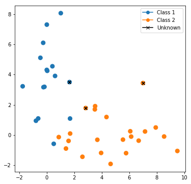

```python
from sklearn.neighbors import KNeighborsClassifier
labelDict = {'Class 1':0,'Class 2':1}
labelDictRev = {0:'Class 1',1:'Class 2'}
D = list(zip(df['X'].values,df['Y'].values))
L = [labelDict[k] for k in df['Class'].values]
neigh = KNeighborsClassifier(n_neighbors=3)
neigh.fit(D, L)
Dt = list(zip(x3,y3))
Dtp = neigh.predict(Dt)
Dtpc = [labelDictRev[k] for k in Dtp]
x = list(df['X'].values) + list(x3)
y = list(df['Y'].values) + list(y3)
classes = list(df['Class'].values) + list(Dtpc)
cols = [colordict[k] for k in classes]
plt.figure(figsize=(6, 6))
plt.scatter(x,y,color=cols,s=65)
plt.scatter(x3,y3,color='black',marker='x',s=35)
plt.legend(handles=legend_elements)
plt.show()
```

### References

https://en.wikipedia.org/wiki/K-nearest_neighbors_algorithm